# MY457/MY557: Causal Inference for Experimental and Observational Studies

Class 5: Regression Discontinuity Designs

First, we will load in some required packages:

```r
library(dplyr)
library(ggplot2)
library(knitr)
library(rdrobust)
library(rddensity)
library(rddtools)
library(ggthemes)
```

# (1) First in-class exercise: Implementing estimation for regression discontinuity designs

In this part of the seminar we show examples of how to estimate the treatment effect using RDD. This is done using a single simulated dataset, for demonstration purposes. We will mostly focus functions from the rdrobust package. Let’s load the dataset.

```r
# LOAD DATA
df <- readRDS("simdata.rds") %>% mutate(X = X - c)
```

[A] RDD plot: First, exploring the data graphically using the basic RDD plot:

```r
# PLOT DATA: OUTCOME VS. RUNNING VARIABLE (LINEAR FIT)
temp <- df %>%
  mutate(X = round(X, 3)) %>%
  group_by(X, Outcome2) %>% summarize(Y = mean(Y, na.rm = T)) %>% ungroup()
```

[output not shown]

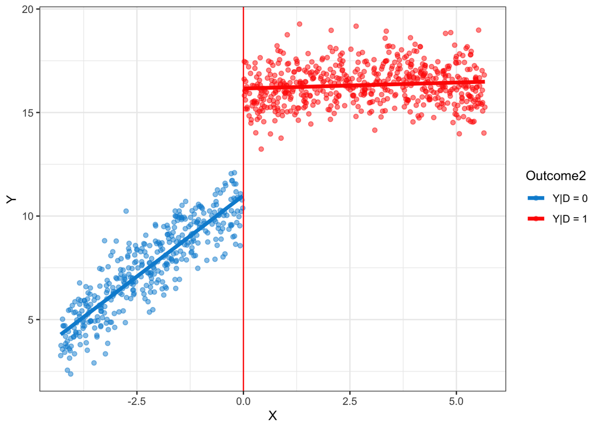

```r
ggplot() +
  geom_jitter(data = temp, aes(x = X, y = Y, color = Outcome2), alpha = 0.5) +
  geom_smooth(data = temp, aes(x = X, y = Y, color = Outcome2), size = 1.5, method = "lm", formula = y ~ x, se = F) +
  geom_vline(xintercept = 0, color = 'red') +
  scale_color_fivethirtyeight() + theme_bw()
```

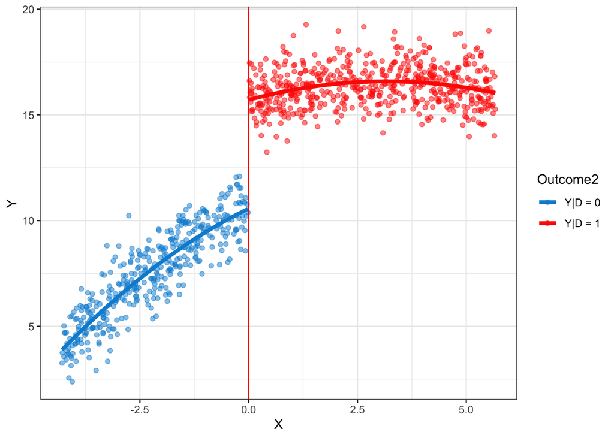

```r
# PLOT DATA: OUTCOME VS. RUNNING VARIABLE (QUADRATIC FIT)
ggplot() +
  geom_jitter(data = temp, aes(x = X, y = Y, color = Outcome2), alpha = 0.5) +
  geom_smooth(data = temp, aes(x = X, y = Y, color = Outcome2), size = 1.5, method = "lm", formula = y ~ poly(x, 2), se = F) +
  geom_vline(xintercept = 0, color = 'red') +
  scale_color_fivethirtyeight() + theme_bw()
```

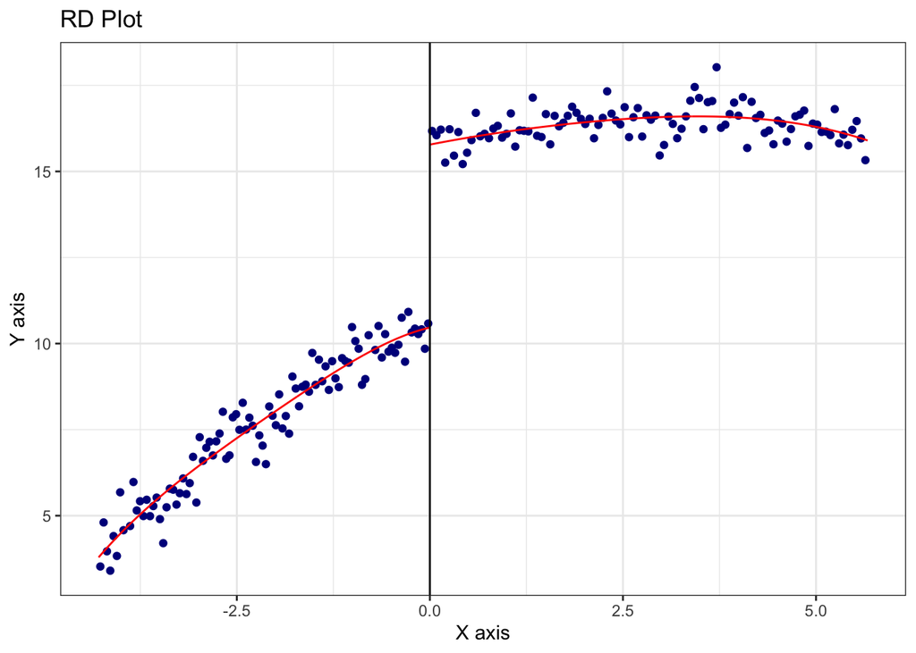

```r
# PLOT DATA: OUTCOME VS. RUNNING VARIABLE (QUADRATIC FIT)
rdplot(df$Y, df$X, c = 0, nbins = 100)
```

[B] Selecting the bandwidth: there are different version how to determine the bandwidth size. One “modern” way of selecting bandwidth size is by using the method proposed by Calonico, Cattaneo and Titiunik (2014a), Calonico, Cattaneo and Farrell (2018), Calonico, Cattaneo, Farrell and Titiunik (2019) and Calonico, Cattaneo and Farrell (2020). The function allows you to define different parameters, including the kernel type and the number of polynomials (of the running variable) included on the right-hand-side.

```r
# BANDWIDTH SELECTION
bw <- rdbwselect(y = df$Y, x = df$X, c = 0, p = 1, kernel = 'triangular', bwselect = 'mserd') %>% .[["bws"]] %>% .[1]
bw
```

```
## [1] 1.323006
```

[C] RDD estimation: to estimate the ATT, we only one function: rdrobust. Again, this function enables to set various parameter values. Let’s play around with some of them.

```r
# 1. LINEAR FORM
rdrobust(y = df$Y, x = df$X, c = 0, p = 1, q = 2, h = bw, kernel = "tri", all = T) %>% summary()
```

```
## Sharp RD estimates using local polynomial regression.
##
## Number of Obs.                 1000
## BW type                      Manual
## Kernel                   Triangular
## VCE method                       NN
##
## Number of Obs.                  418          582
## Eff. Number of Obs.             110          146
## Order est. (p)                    1            1
## Order bias  (q)                   2            2
## BW est. (h)                   1.323        1.323
## BW bias (b)                   1.323        1.323
## rho (h/b)                     1.000        1.000
## Unique Obs.                     418          582
##
## =============================================================================
##         Method     Coef. Std. Err.         z     P>|z|      [ 95% C.I. ]
## =============================================================================
##   Conventional     5.265     0.274    19.236     0.000     [4.728 , 5.801]
## Bias-Corrected     5.611     0.274    20.499     0.000     [5.074 , 6.147]
##         Robust     5.611     0.382    14.683     0.000     [4.862 , 6.360]
## =============================================================================
```

```r
# 2. QUADRATIC FORM
rdrobust(y = df$Y, x = df$X, c = 0, p = 2, h = bw, kernel = "tri", all = T) %>% summary()
```

```
## Sharp RD estimates using local polynomial regression.
##
## Number of Obs.                 1000
## BW type                      Manual
## Kernel                   Triangular
## VCE method                       NN
##
## Number of Obs.                  418          582
## Eff. Number of Obs.             110          146
## Order est. (p)                    2            2
## Order bias  (q)                   3            3
## BW est. (h)                   1.323        1.323
## BW bias (b)                   1.323        1.323
## rho (h/b)                     1.000        1.000
## Unique Obs.                     418          582
##
## =============================================================================
##         Method     Coef. Std. Err.         z     P>|z|      [ 95% C.I. ]
## =============================================================================
##   Conventional     5.611     0.382    14.683     0.000     [4.862 , 6.360]
## Bias-Corrected     6.078     0.382    15.906     0.000     [5.329 , 6.827]
##         Robust     6.078     0.468    12.975     0.000     [5.160 , 6.996]
## =============================================================================
```

```r
# 3. INCREASE BANDWIDTH SIZE
rdrobust(y = df$Y, x = df$X, c = 0, p = 1, h = bw*2, kernel = "tri", all = T) %>% summary()
```

```
## Sharp RD estimates using local polynomial regression.
##
## Number of Obs.                 1000
## BW type                      Manual
## Kernel                   Triangular
## VCE method                       NN
##
## Number of Obs.                  418          582
## Eff. Number of Obs.             254          265
## Order est. (p)                    1            1
## Order bias  (q)                   2            2
## BW est. (h)                   2.646        2.646
## BW bias (b)                   2.646        2.646
## rho (h/b)                     1.000        1.000
## Unique Obs.                     418          582
##
## =============================================================================
##         Method     Coef. Std. Err.         z     P>|z|      [ 95% C.I. ]
## =============================================================================
##   Conventional     5.118     0.201    25.402     0.000     [4.723 , 5.512]
## Bias-Corrected     5.346     0.201    26.535     0.000     [4.951 , 5.741]
##         Robust     5.346     0.285    18.777     0.000     [4.788 , 5.904]
## =============================================================================
```

```r
# 4. DECREASE BANDWIDTH SIZE
rdrobust(y = df$Y, x = df$X, c = 0, p = 1, h = bw/3, kernel = "tri", all = T) %>% summary()
```

```
## Sharp RD estimates using local polynomial regression.
##
## Number of Obs.                 1000
## BW type                      Manual
## Kernel                   Triangular
## VCE method                       NN
##
## Number of Obs.                  418          582
## Eff. Number of Obs.              38           51
## Order est. (p)                    1            1
## Order bias  (q)                   2            2
## BW est. (h)                   0.441        0.441
## BW bias (b)                   0.441        0.441
## rho (h/b)                     1.000        1.000
## Unique Obs.                     418          582
##
## =============================================================================
##         Method     Coef. Std. Err.         z     P>|z|      [ 95% C.I. ]
## =============================================================================
##   Conventional     6.021     0.420    14.340     0.000     [5.198 , 6.844]
## Bias-Corrected     6.348     0.420    15.118     0.000     [5.525 , 7.171]
##         Robust     6.348     0.549    11.557     0.000     [5.271 , 7.425]
## =============================================================================
```

```r
# 5. CHANGE THE KERNEL FUNCTION TO UNIFORM
rdrobust(y = df$Y, x = df$X, c = 0, p = 1, h = bw, kernel = "uniform", all = T) %>% summary()
```

```
## Sharp RD estimates using local polynomial regression.
##
## Number of Obs.                 1000
## BW type                      Manual
## Kernel                      Uniform
## VCE method                       NN
##
## Number of Obs.                  418          582
## Eff. Number of Obs.             110          146
## Order est. (p)                    1            1
## Order bias  (q)                   2            2
## BW est. (h)                   1.323        1.323
## BW bias (b)                   1.323        1.323
## rho (h/b)                     1.000        1.000
## Unique Obs.                     418          582
##
## =============================================================================
##         Method     Coef. Std. Err.         z     P>|z|      [ 95% C.I. ]
## =============================================================================
##   Conventional     5.128     0.258    19.894     0.000     [4.622 , 5.633]
## Bias-Corrected     5.487     0.258    21.289     0.000     [4.982 , 5.992]
##         Robust     5.487     0.379    14.473     0.000     [4.744 , 6.230]
## =============================================================================
```

[D] Checks to assess sorting/manipulation: we can test whether the density changes discontinously around the cut-off with the McCracy test.

```r
# SORTING/MANIPULATION TEST: (see McCracy 2008)
dens_test <- rddensity(X = df$X)
dens_test[["test"]][["p_jk"]] # p-value of McCracy test
```

```
## [1] 0.3826685
```

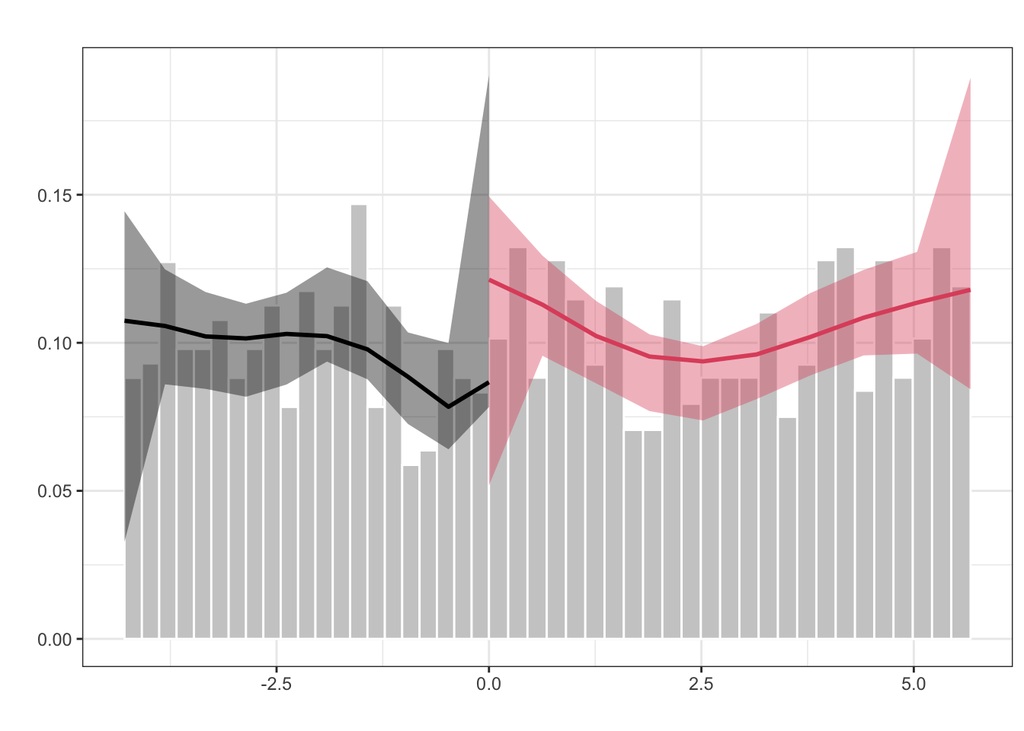

[output not shown]

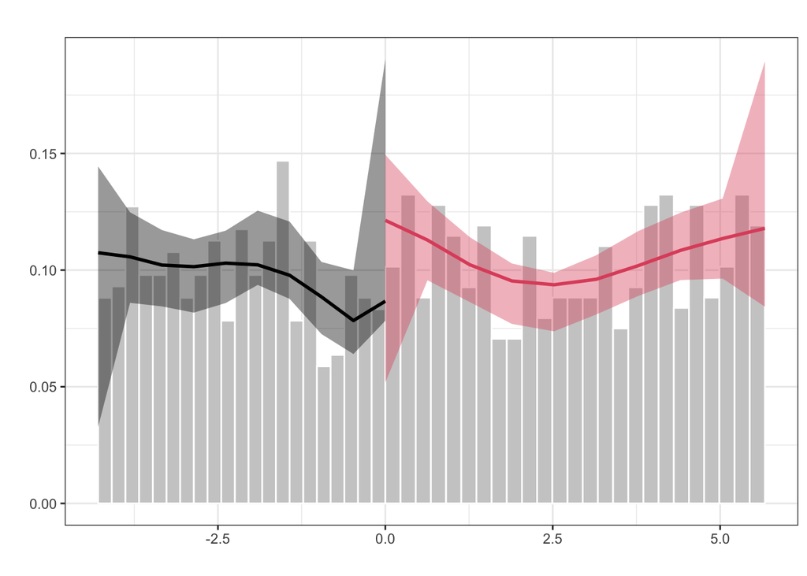

```r
rdplotdensity(dens_test, df$X, histFillCol = 'gray80', histFillShade = 1, CIshade = 0.4, lwd = 1)
```